# 2D Single Molecule Fitting with R

Bob Turner

A core function of software for single molecule localisation microscopy techniques (such as PALM and STORM) is to take an image of the light coming from a molecule and determine its location. This is often achieved by modelling the distribution of light on the camera as a 2D Gaussian function, or some variant of this. In this coding note I will show how R can be used to do this. If you’re used to using off the shelf software for this (either commercial e.g. NSTORM, or open source e.g. ThunderSTORM) I hope this provides some insight into what’s going on under the hood. I’ve made a few simplifcations compared to how I’d do this in a software package, just to make things easier to follow.

If you have any comments or suggestions, please drop me a line at bob.turner.uk at gmail.com.

## Simulate a 2D Gaussian with noise

The first thing I’m going to do is simulate some data to fit - this should look much like the light coming from a single molecule hitting a camera. I’m going to use this formula as my model:

$$z=ae^{-1\Big(\frac{(x-b)^2}{2c^2}+\frac{(y-d)^2}{2e^2}\Big)}$$

This can be defined as an R formula like this.

```r
myGaussian2D.formula<-as.formula(z~a*exp(-1*((((x-b)*(x-b)/2/c/c))+((y-d)*(y-d)/2/e/e))))
```

The parameters that we’re most interesting in are b and d - these are the x and y co-ordinates of the molecule.

For the simulation we will create a set of x and y positions representing a small, square patch of pixels on our camera. We will then apply the fomula that has just been defined to create the simulated data.

```r
set.seed(2)
size<-10 #The dimensions of our square patch of pixels.
x_centre=runif(1,1,size)
y_centre=runif(1,1,size)
parameters<-c(5, x_centre, 1, y_centre, 1)
names(parameters)=c("a","b","c","d","e")
head(parameters)
```

```
       a        b        c        d        e
5.000000 2.663940 1.000000 7.321366 1.000000
```

The co-ordinates of the “molecule” have been randomly generated, other paramters have been set to default values. We will now create a list of pixel values and assign them using the formula.

```r
x<-rep(1:size,times=1,each=size)
y<-rep(1:size,times=size)
mydata<-data.frame(x,y)
mydata$a=parameters["a"]
mydata$b=parameters["b"]
mydata$c=parameters["c"]
mydata$d=parameters["d"]
mydata$e=parameters["e"]
library(lazyeval)
mydata$z<-f_eval(myGaussian2D.formula, mydata)+rnorm(size*size,0,0.1)
head(mydata)
```

|  | x | y | a | b | c | d | e | z |
| --- | --- | --- | --- | --- | --- | --- | --- | --- |
| 1 | 1 | 1 | 5 | 2.66394 | 1 | 7.321366 | 1 | 0.018484921 |
| 2 | 1 | 2 | 5 | 2.66394 | 1 | 7.321366 | 1 | 0.158785422 |
| 3 | 1 | 3 | 5 | 2.66394 | 1 | 7.321366 | 1 | -0.112927235 |
| 4 | 1 | 4 | 5 | 2.66394 | 1 | 7.321366 | 1 | -0.002986681 |
| 5 | 1 | 5 | 5 | 2.66394 | 1 | 7.321366 | 1 | 0.097887673 |
| 6 | 1 | 6 | 5 | 2.66394 | 1 | 7.321366 | 1 | 0.593930697 |

I’ve used rnorm to add some noise. This can then be plotted as an image.

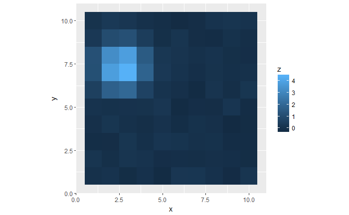

```r
library('ggplot2')
ggplot(mydata,aes(x,y,z))+
  geom_tile(aes(fill=z))+
  coord_fixed()
```

## Fit the simulated data

The built-in nls function in R did not work well for this example but I found a very useful alternative via this article https://www.r-bloggers.com/a-better-nls/. I’ve implemented it for my 2D data here. Fitting works best with some sensible initial guesses for what we expect the values to be.

```r
guesses=c(1, 5, 0.5, 5, 0.5)
names(guesses)=names(parameters)
library(minpack.lm)
myFit<-nlsLM(myGaussian2D.formula, data=mydata, start = guesses)
```

We can compare the fitted parameters to those in the simulation.

```r
data.frame(parameters, coef(myFit))
```

|  | parameters | coef.myFit. |
| --- | --- | --- |
| a | 5.000000 | 5.0380190 |
| b | 2.663940 | 2.6323846 |
| c | 1.000000 | 0.9945952 |
| d | 7.321366 | 7.3458094 |
| e | 1.000000 | 0.9995781 |

And plot the fitted location of the molecule onto our image.

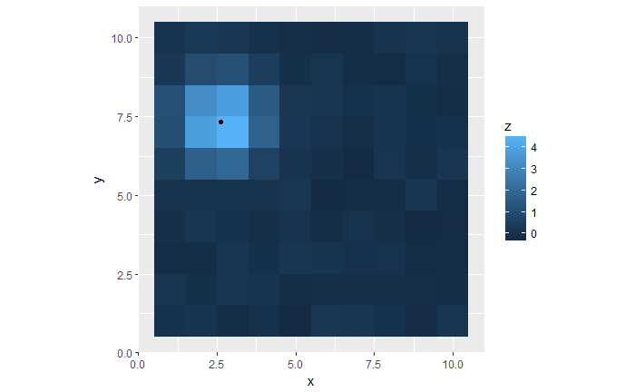

```r
ggplot(mydata,aes(x,y,z))+
  geom_tile(aes(fill=z))+
  coord_fixed()+
  annotate("point", x = coef(myFit)["b"], y = coef(myFit)["d"])
```

By repeating this prcess for all of the molecules in all of the frames of an image stack data set, we can build up a super-resolved image of the sample.